# 【Part 1】Project 1 Seattle Airbnb new

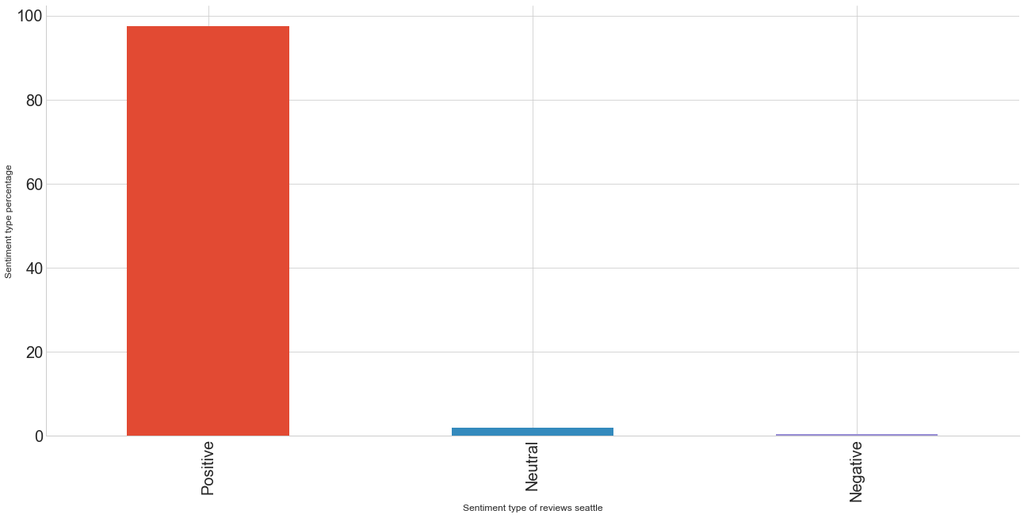

```python
sentiment_type_percentage = reviews_seattle_polarity_desc.Sentiment_Type.value_counts() / reviews_seattle_polarity_desc.shape[0]*100
sentiment_type_percentage.plot(kind='bar',figsize=(22,10),fontsize=20)
plt.xlabel("Sentiment type of reviews seattle")
plt.ylabel("Sentiment type percentage")
sns.despine()
```

From the picture above,I find more than 90% comments are positive.

```python
reviews_seattle_polarity_desc.head()
```

|  | sentence | sentiment | polarity | Sentiment_Type |
| --- | --- | --- | --- | --- |
| 0 | Cute and cozy place. Perfect location to every... | 0.433333 | 0.916667 | Positive |
| 1 | Kelly has a great room in a very central locat... | 0.301136 | 0.493182 | Positive |
| 2 | Very spacious apartment, and in a great neighb... | 0.410417 | 0.610417 | Positive |
| 3 | Close to Seattle Center and all it has to offe... | 0.358333 | 0.508333 | Positive |
| 4 | Kelly was a great host and very accommodating ... | 0.493485 | 0.509091 | Positive |

I try to use primary keys "listing_id" and "reviewer_id",which merged to the table "lists_seattle" to add "Sentiment_Type" feature to the model prediction.

```python
reviews_seattle_selected=reviews_seattle[['listing_id','reviewer_id','reviewer_name','comments']]
```

```python
reviews_seattle_new=pd.merge(reviews_seattle_selected,reviews_seattle_polarity_desc,how='left', left_on='comments',right_on='sentence')
```

```python
reviews_seattle_new.head()
```

|  | listing_id | reviewer_id | reviewer_name | comments | sentence | sentiment | polarity | Sentiment_Type |
| --- | --- | --- | --- | --- | --- | --- | --- | --- |
| 0 | 7202016 | 28943674 | Bianca | Cute and cozy place. Perfect location to every... | Cute and cozy place. Perfect location to every... | 0.433333 | 0.916667 | Positive |
| 1 | 7202016 | 32440555 | Frank | Kelly has a great room in a very central locat... | Kelly has a great room in a very central locat... | 0.301136 | 0.493182 | Positive |
| 2 | 7202016 | 37722850 | Ian | Very spacious apartment, and in a great neighb... | Very spacious apartment, and in a great neighb... | 0.410417 | 0.610417 | Positive |
| 3 | 7202016 | 33671805 | George | Close to Seattle Center and all it has to offe... | Close to Seattle Center and all it has to offe... | 0.358333 | 0.508333 | Positive |
| 4 | 7202016 | 34959538 | Ming | Kelly was a great host and very accommodating ... | Kelly was a great host and very accommodating ... | 0.493485 | 0.509091 | Positive |

```python
lists_seattle_new=pd.merge(lists_seattle,reviews_seattle_new,how='left', left_on=['id','host_id'],right_on=['listing_id','reviewer_id'])
```

```python
lists_seattle_new.head()
```

|  | id | listing_url | scrape_id | last_scraped | name | summary | space | description | experiences_offered | neighborhood_overview | ... | calculated_host_listings_count | reviews_per_month | listing_id | reviewer_id | reviewer_name | comments | sentence | sentiment | polarity | Sentiment_Type |
| --- | --- | --- | --- | --- | --- | --- | --- | --- | --- | --- | --- | --- | --- | --- | --- | --- | --- | --- | --- | --- | --- |
| 0 | 241032 | https://www.airbnb.com/rooms/241032 | 20160104002432 | 2016-01-04 | Stylish Queen Anne Apartment | NaN | Make your self at home in this charming one-be... | Make your self at home in this charming one-be... | none | NaN | ... | 2 | 4.07 | NaN | NaN | NaN | NaN | NaN | NaN | NaN | NaN |
| 1 | 953595 | https://www.airbnb.com/rooms/953595 | 20160104002432 | 2016-01-04 | Bright & Airy Queen Anne Apartment | Chemically sensitive? We've removed the irrita... | Beautiful, hypoallergenic apartment in an extr... | Chemically sensitive? We've removed the irrita... | none | Queen Anne is a wonderful, truly functional vi... | ... | 6 | 1.48 | NaN | NaN | NaN | NaN | NaN | NaN | NaN | NaN |
| 2 | 3308979 | https://www.airbnb.com/rooms/3308979 | 20160104002432 | 2016-01-04 | New Modern House-Amazing water view | New modern house built in 2013. Spectacular s... | Our house is modern, light and fresh with a wa... | New modern house built in 2013. Spectacular s... | none | Upper Queen Anne is a charming neighborhood fu... | ... | 2 | 1.15 | NaN | NaN | NaN | NaN | NaN | NaN | NaN | NaN |
| 3 | 7421966 | https://www.airbnb.com/rooms/7421966 | 20160104002432 | 2016-01-04 | Queen Anne Chateau | A charming apartment that sits atop Queen Anne... | NaN | A charming apartment that sits atop Queen Anne... | none | NaN | ... | 1 | NaN | NaN | NaN | NaN | NaN | NaN | NaN | NaN | NaN |
| 4 | 278830 | https://www.airbnb.com/rooms/278830 | 20160104002432 | 2016-01-04 | Charming craftsman 3 bdm house | Cozy family craftman house in beautiful neighb... | Cozy family craftman house in beautiful neighb... | Cozy family craftman house in beautiful neighb... | none | We are in the beautiful neighborhood of Queen ... | ... | 1 | 0.89 | NaN | NaN | NaN | NaN | NaN | NaN | NaN | NaN |

5 rows × 100 columns

```python
lists_seattle_new[['id','host_id','listing_id','reviewer_id']].head()
```

|  | id | host_id | listing_id | reviewer_id |
| --- | --- | --- | --- | --- |
| 0 | 241032 | 956883 | NaN | NaN |
| 1 | 953595 | 5177328 | NaN | NaN |
| 2 | 3308979 | 16708587 | NaN | NaN |
| 3 | 7421966 | 9851441 | NaN | NaN |
| 4 | 278830 | 1452570 | NaN | NaN |

```python
lists_seattle_new.shape
```

```
(3818, 100)
```

```python
lists_seattle_new[['Sentiment_Type']].isnull().sum().sort_values(ascending = False)
```

```
Sentiment_Type    3818
dtype: int64
```

From the result above,I find I cannot merge "Sentiment_Type" to the table "lists_seattle",maybe the "id" doesn't exactly mean "list_id".

```python
calendar_seattle.head()
```

|  | listing_id | date | available | price |
| --- | --- | --- | --- | --- |
| 0 | 241032 | 2016-01-04 | t | $85.00 |
| 1 | 241032 | 2016-01-05 | t | $85.00 |
| 2 | 241032 | 2016-01-06 | f | NaN |
| 3 | 241032 | 2016-01-07 | f | NaN |
| 4 | 241032 | 2016-01-08 | f | NaN |

# Prepare Data

### After exploring all the three tables of Seattle of Airbnb,I decide to use table of lists_seattle and select some columns which are possibly relatively to price for next analysis.

```python
# select the columns which maybe useful in the following analysis
lists_seattle_data = lists_seattle.loc[:,['name', 'summary', 'space', 'description',
    'host_response_time', 'host_response_rate', 'host_acceptance_rate', 'host_is_superhost',
     'property_type', 'room_type', 'latitude','longitude','square_feet','extra_people','weekly_price','monthly_price',
    'accommodates', 'bathrooms', 'bedrooms', 'beds', 'bed_type','is_location_exact',
    'amenities', 'price', 'cleaning_fee', 'minimum_nights',
    'maximum_nights', 'instant_bookable',
    'cancellation_policy', 'review_scores_rating', 'review_scores_accuracy',
    'review_scores_cleanliness', 'review_scores_checkin', 'review_scores_communication',
    'review_scores_location', 'review_scores_value']]
```

Feature Engineering

```python
#Get lengths of description elements
lists_seattle_data.loc[:,'name_length'] = lists_seattle_data['name'].str.len()
lists_seattle_data.loc[:,'summary_length'] = lists_seattle_data['summary'].str.len()
lists_seattle_data.loc[:,'space_length'] = lists_seattle_data['space'].str.len()
lists_seattle_data.loc[:,'description_length'] = lists_seattle_data['description'].str.len()
lists_seattle_data.loc[:,'amenities_length'] = lists_seattle_data['amenities'].str.len()
lists_seattle_data.loc[:,'name_length'].fillna(0, inplace=True)
lists_seattle_data.loc[:,'summary_length'].fillna(0, inplace=True)
lists_seattle_data.loc[:,'space_length'].fillna(0, inplace=True)
lists_seattle_data.loc[:,'description_length'].fillna(0, inplace=True)
lists_seattle_data.loc[:,'amenities_length'] = lists_seattle_data['amenities'].str.len()

#Drop original description variables
lists_seattle_data = lists_seattle_data.drop(['name', 'summary', 'space', 'description', 'amenities'], 1)
```

```python
#Recode host_response_time to integers as it is a spectrum
lists_seattle_data['host_response_time'].replace('within an hour', 1, inplace=True)
lists_seattle_data['host_response_time'].replace('within a few hours', 2, inplace=True)
lists_seattle_data['host_response_time'].replace('within a day', 3, inplace=True)
lists_seattle_data['host_response_time'].replace('a few days or more', 4, inplace=True)

#Impute missing values using mode
lists_seattle_data['host_response_time'].fillna(lists_seattle_data['host_response_time'].mode()[0], inplace=True)
```

```python
#Convert acceptance/response percentages to numbers
lists_seattle_data['host_acceptance_rate'] = lists_seattle_data['host_acceptance_rate'].replace('%','',regex=True).astype('float64')/100.00
lists_seattle_data['host_response_rate'] = lists_seattle_data['host_response_rate'].replace('%','',regex=True).astype('float64')/100.00

#Impute missing values using mean
lists_seattle_data['host_response_rate'].fillna(lists_seattle_data['host_response_rate'].mean(), inplace=True)
lists_seattle_data['host_acceptance_rate'].fillna(lists_seattle_data['host_acceptance_rate'].mean(), inplace=True)
```

```python
#Change f/t values to binary 0/1
lists_seattle_data['host_is_superhost'].replace('t',1, inplace=True)
lists_seattle_data['host_is_superhost'].replace('f',0, inplace=True)
lists_seattle_data['instant_bookable'].replace('t',1, inplace=True)
lists_seattle_data['instant_bookable'].replace('f',0, inplace=True)

lists_seattle_data['is_location_exact'].replace('t',1, inplace=True)
lists_seattle_data['is_location_exact'].replace('f',0, inplace=True)
```

```python
#Clean property_type category to 5 categories
def property_type_process(value):

    """
    This founction is to clean property_type category to 5 categories.

    Summary or Description of the Function

    Parameters:
    value (series): The column ‘property_type’ of ‘lists_seattle_data’.

    Returns:
    string:Returning the new property type.


    """

    if value not in ['House', 'Apartment', 'Touwnhouse', 'Condominium']:
        return 'Other'
    return value

lists_seattle_data['property_type'] = lists_seattle_data['property_type'].apply(property_type_process)
```

```python
#Clean bed_type to binary real bed or other
def bed_type_process(value):
    if value not in ['Real Bed']:
        return 'Other'
    return value

lists_seattle_data['bed_type'] = lists_seattle_data['bed_type'].apply(bed_type_process)
```

```python
#Convert cleaning fee,price,weekly_price,monthly_price,extra_people,cleaning_fee from strings to numbers
# lists_seattle_data['price'] = lists_seattle_data['price'].str.replace('$', '')
# lists_seattle_data['price'] = lists_seattle_data['price'].str.replace(',', '').astype('float64')

lists_seattle_data['weekly_price'] = lists_seattle_data['weekly_price'].str.replace('$', '')
lists_seattle_data['weekly_price'] = lists_seattle_data['weekly_price'].str.replace(',', '').astype('float64')

lists_seattle_data['monthly_price'] = lists_seattle_data['monthly_price'].str.replace('$', '')
lists_seattle_data['monthly_price'] = lists_seattle_data['monthly_price'].str.replace(',', '').astype('float64')

lists_seattle_data['extra_people'] = lists_seattle_data['extra_people'].str.replace('$', '')
lists_seattle_data['extra_people'] = lists_seattle_data['extra_people'].str.replace(',', '').astype('float64')

lists_seattle_data['cleaning_fee'] = lists_seattle_data['cleaning_fee'].str.replace('$', '')
lists_seattle_data['cleaning_fee'] = lists_seattle_data['cleaning_fee'].str.replace(',', '').astype('float64')
```

```python
##Impute missing values using mode
lists_seattle_data['bathrooms'].fillna(lists_seattle_data['bathrooms'].mode()[0], inplace=True)
lists_seattle_data['bedrooms'].fillna(lists_seattle_data['bedrooms'].mode()[0], inplace=True)
lists_seattle_data['beds'].fillna(lists_seattle_data['beds'].mode()[0], inplace=True)
lists_seattle_data['host_is_superhost'].fillna(lists_seattle_data['host_is_superhost'].mode()[0], inplace=True)

lists_seattle_data['is_location_exact'].fillna(lists_seattle_data['is_location_exact'].mode()[0], inplace=True)
```

```python
# lists_boston_data = lists_boston_data.dropna(subset=['review_scores_rating'], axis=0)
```

```python
##Impute missing values using mean
lists_seattle_data['cleaning_fee'].fillna(lists_seattle_data['cleaning_fee'].mean(), inplace=True)
lists_seattle_data['review_scores_rating'].fillna(lists_seattle_data['review_scores_rating'].mean(), inplace=True)
lists_seattle_data['review_scores_accuracy'].fillna(lists_seattle_data['review_scores_accuracy'].mean(), inplace=True)
lists_seattle_data['review_scores_location'].fillna(lists_seattle_data['review_scores_location'].mean(), inplace=True)
lists_seattle_data['review_scores_value'].fillna(lists_seattle_data['review_scores_value'].mean(), inplace=True)
lists_seattle_data['review_scores_checkin'].fillna(lists_seattle_data['review_scores_checkin'].mean(), inplace=True)
lists_seattle_data['review_scores_communication'].fillna(lists_seattle_data['review_scores_communication'].mean(), inplace=True)
lists_seattle_data['review_scores_cleanliness'].fillna(lists_seattle_data['review_scores_cleanliness'].mean(), inplace=True)
lists_seattle_data['latitude'].fillna(lists_seattle_data['latitude'].mean(), inplace=True)
lists_seattle_data['longitude'].fillna(lists_seattle_data['longitude'].mean(), inplace=True)
lists_seattle_data['square_feet'].fillna(lists_seattle_data['square_feet'].mean(), inplace=True)
lists_seattle_data['extra_people'].fillna(lists_seattle_data['extra_people'].mean(), inplace=True)
lists_seattle_data['weekly_price'].fillna(lists_seattle_data['weekly_price'].mean(), inplace=True)
lists_seattle_data['monthly_price'].fillna(lists_seattle_data['monthly_price'].mean(), inplace=True)
```

```python
lists_seattle_data.info()
```

```
<class 'pandas.core.frame.DataFrame'>
RangeIndex: 3818 entries, 0 to 3817
Data columns (total 36 columns):
host_response_time             3818 non-null float64
host_response_rate             3818 non-null float64
host_acceptance_rate           3818 non-null float64
host_is_superhost              3818 non-null float64
property_type                  3818 non-null object
room_type                      3818 non-null object
latitude                       3818 non-null float64
longitude                      3818 non-null float64
square_feet                    3818 non-null float64
extra_people                   3818 non-null float64
weekly_price                   3818 non-null float64
monthly_price                  3818 non-null float64
accommodates                   3818 non-null int64
bathrooms                      3818 non-null float64
bedrooms                       3818 non-null float64
beds                           3818 non-null float64
bed_type                       3818 non-null object
is_location_exact              3818 non-null int64
price                          3818 non-null float64
cleaning_fee                   3818 non-null float64
minimum_nights                 3818 non-null int64
maximum_nights                 3818 non-null int64
instant_bookable               3818 non-null int64
cancellation_policy            3818 non-null object
review_scores_rating           3818 non-null float64
review_scores_accuracy         3818 non-null float64
review_scores_cleanliness      3818 non-null float64
review_scores_checkin          3818 non-null float64
review_scores_communication    3818 non-null float64
review_scores_location         3818 non-null float64
review_scores_value            3818 non-null float64
name_length                    3818 non-null int64
summary_length                 3818 non-null float64
space_length                   3818 non-null float64
description_length             3818 non-null int64
amenities_length               3818 non-null int64
dtypes: float64(24), int64(8), object(4)
memory usage: 1.0+ MB
```

# Question 1:

There are several variables which are related to review score such as "review_scores_rating","review_scores_accuracy","review_scores_cleanliness",should I put all those variables into the model predicting? and if other variables have the same situation?

```
price                          1.000000
accommodates                   0.652218
bedrooms                       0.627624
weekly_price                   0.626361
beds                           0.588989
cleaning_fee                   0.583274
bathrooms                      0.516009
monthly_price                  0.495664
amenities_length               0.165247
extra_people                   0.127961
space_length                   0.091669
square_feet                    0.084090
review_scores_location         0.068178
review_scores_rating           0.050488
review_scores_cleanliness      0.049385
host_response_time             0.042915
minimum_nights                 0.017297
review_scores_accuracy         0.017278
is_location_exact              0.016056
name_length                    0.013404
host_is_superhost              0.012131
review_scores_communication    0.011802
review_scores_checkin          0.007154
host_acceptance_rate           0.004848
maximum_nights                -0.003336
description_length            -0.006758
latitude                      -0.008904
host_response_rate            -0.012718
summary_length                -0.028266
instant_bookable              -0.031712
review_scores_value           -0.037939
longitude                     -0.102420
Name: price, dtype: float64
```

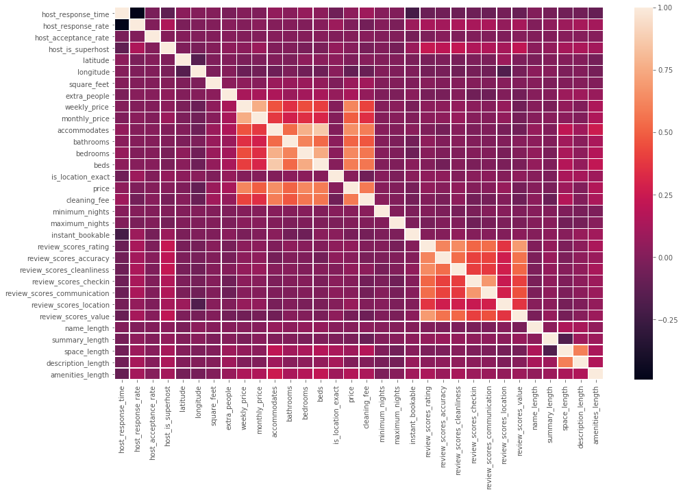

```python
#Correlation Matrix
fig, ax = plt.subplots(figsize=(16,10))
corr = lists_seattle_data.corr()
corr = (corr)
sns.heatmap(corr,
            xticklabels=corr.columns.values,
            yticklabels=corr.columns.values, linewidths=.5, ax=ax)
corr['price'].sort_values(ascending=False)
```